# birthweight_smoking

## Birthweight Smoking Analysis

Initial Setup

```python
import numpy as np
import matplotlib.pyplot as plt
import pandas as pd
import statsmodels.api as sm

# Converted to csv since pandas wasn't playing nice
smoking_df = pd.read_csv("birthweight_smoking-1.csv")
# Reorder according to the documentation order
smoking_df = smoking_df[["birthweight", "smoker", "age", "educ", "unmarried", "alcohol", "drinks", "tripre1", "tripre2", "tripre3", "tripre0", "nprevist"]]
display(smoking_df)
```

|  | birthweight | smoker | age | educ | unmarried | alcohol | drinks | tripre1 | tripre2 | tripre3 | tripre0 | nprevist |
| --- | --- | --- | --- | --- | --- | --- | --- | --- | --- | --- | --- | --- |
| 0 | 4253 | 1 | 27 | 12 | 1 | 0 | 0 | 1 | 0 | 0 | 0 | 12 |
| 1 | 3459 | 0 | 24 | 16 | 0 | 0 | 0 | 0 | 1 | 0 | 0 | 5 |
| 2 | 2920 | 1 | 23 | 11 | 0 | 0 | 0 | 1 | 0 | 0 | 0 | 12 |
| 3 | 2600 | 0 | 28 | 17 | 0 | 0 | 0 | 1 | 0 | 0 | 0 | 13 |
| 4 | 3742 | 0 | 27 | 13 | 0 | 0 | 0 | 1 | 0 | 0 | 0 | 9 |
| ... | ... | ... | ... | ... | ... | ... | ... | ... | ... | ... | ... | ... |
| 2995 | 2520 | 0 | 42 | 12 | 0 | 0 | 0 | 0 | 1 | 0 | 0 | 15 |
| 2996 | 3062 | 0 | 27 | 17 | 0 | 0 | 0 | 1 | 0 | 0 | 0 | 10 |
| 2997 | 3799 | 0 | 28 | 12 | 0 | 0 | 0 | 0 | 1 | 0 | 0 | 11 |
| 2998 | 2070 | 1 | 21 | 11 | 0 | 0 | 0 | 1 | 0 | 0 | 0 | 10 |
| 2999 | 2948 | 0 | 23 | 14 | 0 | 0 | 0 | 1 | 0 | 0 | 0 | 11 |

3000 rows × 12 columns

#### 1. Get to know your data. Make histograms and summary statistics of your data to get a sense of distributions.

```
       birthweight       smoker          age         educ    unmarried  \
count  3000.000000  3000.000000  3000.000000  3000.000000  3000.000000
mean   3382.933667     0.194000    26.889000    12.907000     0.226667
std     592.162889     0.395495     5.362487     2.166699     0.418745
min     425.000000     0.000000    14.000000     0.000000     0.000000
25%    3062.000000     0.000000    23.000000    12.000000     0.000000
50%    3420.000000     0.000000    27.000000    12.000000     0.000000
75%    3750.000000     0.000000    31.000000    14.000000     0.000000
max    5755.000000     1.000000    44.000000    17.000000     1.000000

           alcohol       drinks      tripre1      tripre2      tripre3  \
count  3000.000000  3000.000000  3000.000000  3000.000000  3000.000000
mean      0.019333     0.058333     0.804000     0.153000     0.033000
std       0.137717     0.687814     0.397035     0.360048     0.178666
min       0.000000     0.000000     0.000000     0.000000     0.000000
25%       0.000000     0.000000     1.000000     0.000000     0.000000
50%       0.000000     0.000000     1.000000     0.000000     0.000000
75%       0.000000     0.000000     1.000000     0.000000     0.000000
max       1.000000    21.000000     1.000000     1.000000     1.000000

           tripre0     nprevist
count  3000.000000  3000.000000
mean      0.010000    10.991667
std       0.099515     3.672069
min       0.000000     0.000000
25%       0.000000     9.000000
50%       0.000000    12.000000
75%       0.000000    13.000000
max       1.000000    35.000000
```

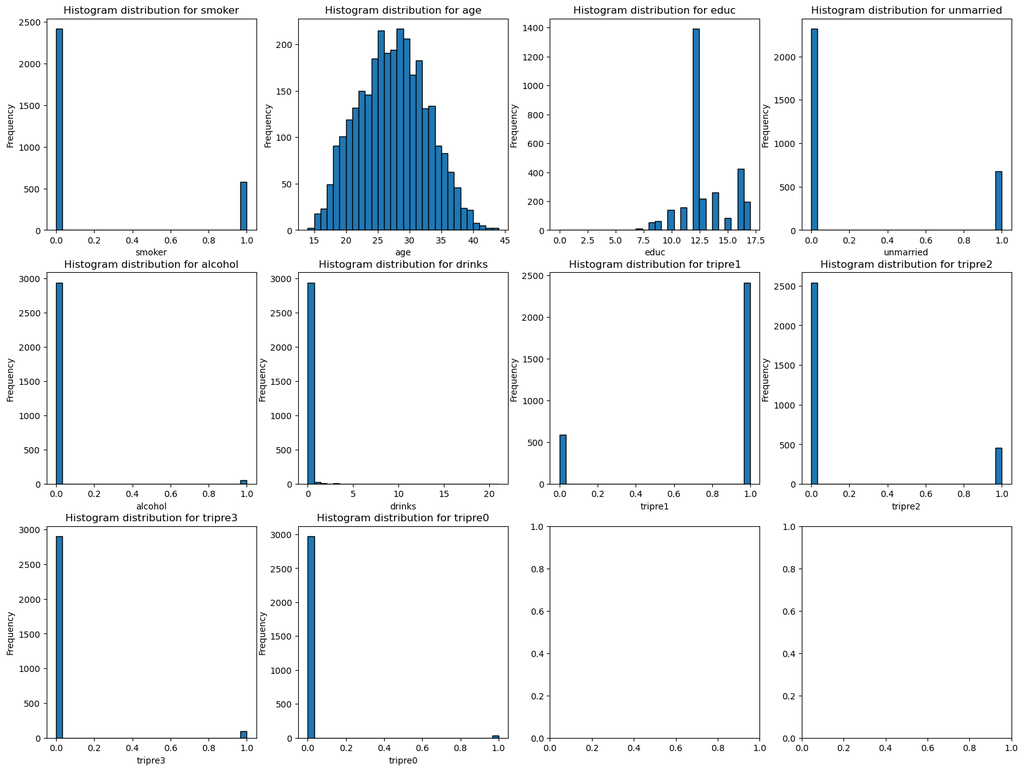

```python
# Summary statistics for all numerical columns
print(smoking_df.describe())

# Create histograms for relevant variables
fig, axes = plt.subplots(3, 4, figsize=(20, 15))
axes = axes.flatten()

predictor_vars = list(smoking_df.columns)[1:11]
for i, predictor_var in enumerate(predictor_vars):
    axes[i].hist(smoking_df[predictor_var], bins=30, edgecolor="black")
    axes[i].set_title(f"Histogram distribution for {predictor_var}")
    axes[i].set_xlabel(predictor_var)
    axes[i].set_ylabel("Frequency")

plt.show()
```

##### A. What is the average value of birthweight for mothers who smoke? For mothers who don’t smoke?

```python
smoker_avg_birthweight = smoking_df[smoking_df["smoker"] == 1]["birthweight"].mean()
non_smoker_avg_birthweight = smoking_df[smoking_df["smoker"] == 0]["birthweight"].mean()

print(f"{smoker_avg_birthweight=}")
print(f"{non_smoker_avg_birthweight=}")
```

```
smoker_avg_birthweight=3178.831615120275
non_smoker_avg_birthweight=3432.0599669148055
```

#### 2. Consider associations. Plot each predictor (variables 2 through 11 in the pdf data description) against the response (birthweight). You could also do a quick line fit or get its correlation. Correlation is with “cor()”. A line fit can be achieved using the linear model function. Two commands, model<-lm(response~predictor), followed by summary(model) will give you least squares result for an individual predictor (e.g., smoker) against the response. This will give you a rough idea of what might be important. Try for regressions 2 through 11.

```
smoker model.summary()=<class 'statsmodels.iolib.summary.Summary'>
"""
                            OLS Regression Results
==============================================================================
Dep. Variable:            birthweight   R-squared:                       0.029
Model:                            OLS   Adj. R-squared:                  0.028
Method:                 Least Squares   F-statistic:                     88.28
Date:                Sun, 10 Aug 2025   Prob (F-statistic):           1.09e-20
Time:                        05:23:37   Log-Likelihood:                -23364.
No. Observations:                3000   AIC:                         4.673e+04
Df Residuals:                    2998   BIC:                         4.674e+04
Df Model:                           1
Covariance Type:            nonrobust
==============================================================================
                 coef    std err          t      P>|t|      [0.025      0.975]
------------------------------------------------------------------------------
const       3432.0600     11.871    289.115      0.000    3408.784    3455.336
smoker      -253.2284     26.951     -9.396      0.000    -306.074    -200.383
==============================================================================
Omnibus:                      473.891   Durbin-Watson:                   1.973
Prob(Omnibus):                  0.000   Jarque-Bera (JB):             1247.472
Skew:                          -0.858   Prob(JB):                    1.30e-271
Kurtosis:                       5.652   Cond. No.                         2.64
==============================================================================

Notes:
[1] Standard Errors assume that the covariance matrix of the errors is correctly specified.
"""
age model.summary()=<class 'statsmodels.iolib.summary.Summary'>
"""
                            OLS Regression Results
==============================================================================
Dep. Variable:            birthweight   R-squared:                       0.006
Model:                            OLS   Adj. R-squared:                  0.006
Method:                 Least Squares   F-statistic:                     19.35
Date:                Sun, 10 Aug 2025   Prob (F-statistic):           1.13e-05
Time:                        05:23:37   Log-Likelihood:                -23398.
No. Observations:                3000   AIC:                         4.680e+04
Df Residuals:                    2998   BIC:                         4.681e+04
Df Model:                           1
```

[output cut: 225 more lines]

```
==============================================================================
                 coef    std err          t      P>|t|      [0.025      0.975]
------------------------------------------------------------------------------
const       3390.2825     10.784    314.368      0.000    3369.137    3411.428
tripre0     -734.8825    107.844     -6.814      0.000    -946.339    -523.426
==============================================================================
Omnibus:                      425.987   Durbin-Watson:                   1.988
Prob(Omnibus):                  0.000   Jarque-Bera (JB):             1072.738
Skew:                          -0.792   Prob(JB):                    1.14e-233
Kurtosis:                       5.464   Cond. No.                         10.1
==============================================================================

Notes:
[1] Standard Errors assume that the covariance matrix of the errors is correctly specified.
"""
```

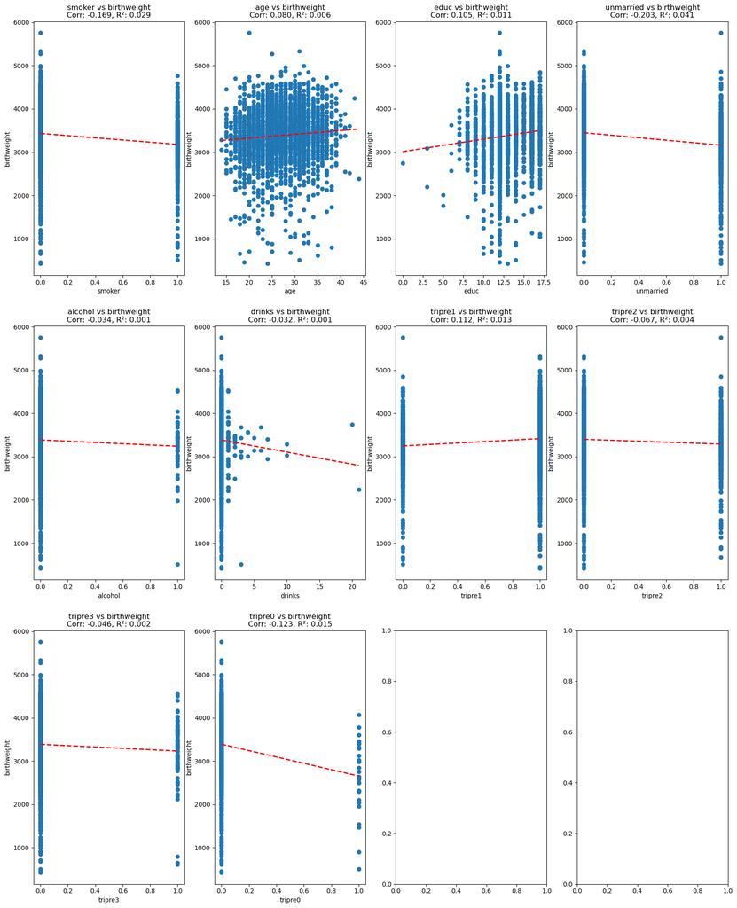

```python
predictors = list(smoking_df.columns)[1:11]

fig, axes = plt.subplots(3, 4, figsize=(20, 25))
axes = axes.flatten()

correlations = {}
regression_results = {}

for i, predictor in enumerate(predictors):
    # Calculate correlation
    correlation = smoking_df[predictor].corr(smoking_df["birthweight"])
    correlations[predictor] = correlation

    # Perform simple linear regression
    intercept = sm.add_constant(smoking_df[predictor])
    model = sm.OLS(smoking_df["birthweight"], intercept).fit()
    regression_results[predictor] = model

    # Plot predictor vs birthweight
    axes[i].scatter(smoking_df[predictor], smoking_df["birthweight"])

    # Add regression line
    x_range = np.linspace(smoking_df[predictor].min(), smoking_df[predictor].max(), 100)
    y_pred = model.params[0] + model.params[1] * x_range
    axes[i].plot(x_range, y_pred, "r--", linewidth=2)

    axes[i].set_xlabel(predictor)
    axes[i].set_ylabel('birthweight')
    axes[i].set_title(f'{predictor} vs birthweight\nCorr: {correlation:.3f}, R²: {model.rsquared:.3f}')

    print(f"{predictor} {model.summary()=}")

plt.show()
```

##### A. What does a regression of birthweight on the binary variable smoker suggest about the relationship between maternal smoking and infant birthweight?

Looking at the regression of birthweight on smoker, there seems to be a negative correlation between maternal smoking and infant birthweight, that is, smoking seems to have a negative effect and reduce the infant birthweight.

##### B. Do you think the regression above accurately captures the impact of smoking on birthweight? (Consider the assumptions of the linear regression model and whether they are met. Hint: do you think smoking is uncorrelated with other factors that cause low birthweight?)

The regression above likely does not solely accurately capture the impact of smoking on birthweight, as some of the key assumptions of the linear regression model include normality and independence, both of which are likely correlated to other factors that cause low birthweight due to lifestyle choices or tightly coupled backgrounds.

##### C. Regress birthweight on smoker, alcohol, and nprevist. Explain why the exclusion of these variables could lead to a biased regression coefficient in (a) above. Is the estimated effect of smoking on birthweight substantially different from the regression in (a) above?

```python
x_multi = sm.add_constant(smoking_df[["smoker", "alcohol", "nprevist"]])
multi_model = sm.OLS(smoking_df["birthweight"], x_multi).fit()
print(f"{multi_model.summary()=}")

pct_change = abs((-253.2284 - (-217.5801)) / -253.228)
print(f"{pct_change=}")
```

```
multi_model.summary()=<class 'statsmodels.iolib.summary.Summary'>
"""
                            OLS Regression Results
==============================================================================
Dep. Variable:            birthweight   R-squared:                       0.073
Model:                            OLS   Adj. R-squared:                  0.072
Method:                 Least Squares   F-statistic:                     78.47
Date:                Sun, 10 Aug 2025   Prob (F-statistic):           7.31e-49
Time:                        05:56:49   Log-Likelihood:                -23294.
No. Observations:                3000   AIC:                         4.660e+04
Df Residuals:                    2996   BIC:                         4.662e+04
Df Model:                           3
Covariance Type:            nonrobust
==============================================================================
                 coef    std err          t      P>|t|      [0.025      0.975]
------------------------------------------------------------------------------
const       3051.2486     34.016     89.701      0.000    2984.552    3117.946
smoker      -217.5801     26.680     -8.155      0.000    -269.892    -165.268
alcohol      -30.4913     76.234     -0.400      0.689    -179.968     118.985
nprevist      34.0699      2.855     11.933      0.000      28.472      39.668
==============================================================================
Omnibus:                      374.095   Durbin-Watson:                   1.974
Prob(Omnibus):                  0.000   Jarque-Bera (JB):              869.220
Skew:                          -0.729   Prob(JB):                    1.78e-189
Kurtosis:                       5.197   Cond. No.                         85.2
==============================================================================

Notes:
[1] Standard Errors assume that the covariance matrix of the errors is correctly specified.
"""
pct_change=0.1407755066580315
```

The exclusion of these variables could lead to a biased regression other variables like alcohol and nprevist could also have an effect on birthweight, so smoking could appear to be more harmful than it actually is on its own. The coefficient seems to have changed by ~14%, which is a relatively large amount to have shifted just due to two variables, so the impact is indeed somewhat substantially different.

##### D. Jane smoked during her pregnancy, did not drink alcohol, and had 8 prenatal care visits. Use the regression in (c) to predict the birthweight of Jane’s infant.

```python
smoker_jane = 1
alcohol_jane = 0
nprevist_jane = 8

intercept, smoker_coeff, alcohol_coeff, nprevisit_coeff = multi_model.params[0:4]

birthweight_jane = intercept + smoker_coeff * smoker_jane + alcohol_coeff * alcohol_jane + nprevisit_coeff * nprevist_jane

print(f"{birthweight_jane=}")
```

```
birthweight_jane=3106.227800368578
```

#### 3. An alternative way to control for prenatal visits is to use binary variables tripre0 through tripre3. Regress birthweight on smoker, alcohol, tripre0, tripre2, and tripre3.

```python
x_tri_multi = sm.add_constant(smoking_df[["smoker", "alcohol", "tripre0", "tripre2", "tripre3"]])
x_tri_multi_model = sm.OLS(smoking_df["birthweight"], x_tri_multi).fit()
print(f"{x_tri_multi_model.summary()=}")
```

```
x_tri_multi_model.summary()=<class 'statsmodels.iolib.summary.Summary'>
"""
                            OLS Regression Results
==============================================================================
Dep. Variable:            birthweight   R-squared:                       0.046
Model:                            OLS   Adj. R-squared:                  0.045
Method:                 Least Squares   F-statistic:                     29.18
Date:                Sun, 10 Aug 2025   Prob (F-statistic):           5.20e-29
Time:                        06:04:13   Log-Likelihood:                -23336.
No. Observations:                3000   AIC:                         4.668e+04
Df Residuals:                    2994   BIC:                         4.672e+04
Df Model:                           5
Covariance Type:            nonrobust
==============================================================================
                 coef    std err          t      P>|t|      [0.025      0.975]
------------------------------------------------------------------------------
const       3454.5493     12.650    273.077      0.000    3429.745    3479.354
smoker      -228.8476     27.165     -8.424      0.000    -282.111    -175.584
alcohol      -15.1000     77.541     -0.195      0.846    -167.138     136.938
tripre0     -697.9687    106.876     -6.531      0.000    -907.526    -488.411
tripre2     -100.8373     29.619     -3.404      0.001    -158.913     -42.762
tripre3     -136.9553     59.581     -2.299      0.022    -253.780     -20.131
==============================================================================
Omnibus:                      443.968   Durbin-Watson:                   1.976
Prob(Omnibus):                  0.000   Jarque-Bera (JB):             1157.634
Skew:                          -0.811   Prob(JB):                    4.20e-252
Kurtosis:                       5.575   Cond. No.                         10.5
==============================================================================

Notes:
[1] Standard Errors assume that the covariance matrix of the errors is correctly specified.
"""
```

##### A. Why is tripre1 excluded from the model? What happens if you include it in the regression?

```python
x_tri_full_multi = sm.add_constant(smoking_df[["smoker", "alcohol", "tripre0", "tripre1", "tripre2", "tripre3"]])
x_tri_full_multi = sm.OLS(smoking_df["birthweight"], x_tri_multi).fit()
print(f"{x_tri_full_multi.summary()=}")
```

[output not shown]

##### B. The estimated coefficient on tripre0 is large and negative. What does this coefficient measure? Interpret its value.

This coefficient measures the difference in average birthweight of babies to mothers who did not have any prenatal care visits compared to mothers who had their prenatal care visit in the first trimester. The ~-698 value indicates that the average birthweight of babies with no prenatal care visits is approximately 698 grams less than those born to mothers with their first prenatal care visit in the first trimester.

##### D. Does the regression in (3) explain a larger fraction of the variance in birthweight than the regression in (2c)? (Hint: consider R2 .)

The regression in (3) has R^2 value of 0.046 while the regression in part (2C) has R^2 value of 0.073. We can therefore determine that with the smaller R^2 value, it actually explains a **lower fraction** of the variance.

#### 4. Consider adding an additional regressor: Regress birthweight on smoker, alcohol, nprevist, and unmarried.

```python
x_unmarried_multi = sm.add_constant(smoking_df[["smoker", "alcohol", "nprevist", "unmarried"]])
x_unmarried_multi_model = sm.OLS(smoking_df["birthweight"], x_unmarried_multi).fit()
print(f"{x_unmarried_multi_model.summary()=}")
```

```
x_unmarried_multi_model.summary()=<class 'statsmodels.iolib.summary.Summary'>
"""
                            OLS Regression Results
==============================================================================
Dep. Variable:            birthweight   R-squared:                       0.089
Model:                            OLS   Adj. R-squared:                  0.087
Method:                 Least Squares   F-statistic:                     72.79
Date:                Sun, 10 Aug 2025   Prob (F-statistic):           6.12e-59
Time:                        19:07:08   Log-Likelihood:                -23268.
No. Observations:                3000   AIC:                         4.655e+04
Df Residuals:                    2995   BIC:                         4.658e+04
Df Model:                           4
Covariance Type:            nonrobust
==============================================================================
                 coef    std err          t      P>|t|      [0.025      0.975]
------------------------------------------------------------------------------
const       3134.4000     35.656     87.907      0.000    3064.487    3204.313
smoker      -175.3769     27.099     -6.472      0.000    -228.511    -122.243
alcohol      -21.0835     75.607     -0.279      0.780    -169.331     127.164
nprevist      29.6025      2.898     10.213      0.000      23.920      35.286
unmarried   -187.1332     26.007     -7.195      0.000    -238.128    -136.139
==============================================================================
Omnibus:                      369.861   Durbin-Watson:                   1.967
Prob(Omnibus):                  0.000   Jarque-Bera (JB):              880.870
Skew:                          -0.714   Prob(JB):                    5.27e-192
Kurtosis:                       5.238   Cond. No.                         85.2
==============================================================================

Notes:
[1] Standard Errors assume that the covariance matrix of the errors is correctly specified.
"""
```

##### A. Compare the coefficient on smoker in this regression to the coefficients on smoker in regressions (2a) and (2c). What is the estimated effect of smoking on birthweight in each regression?

The coefficient on smoker in this regression is ~-175, which indicates a 175 gram decrease in birthweight for mothers who smoke relative to those who do not in this model. This is lower than the coefficients from (2A) and (2C), which are ~-253 and ~-218 respectively, which indicates a much larger decrease in birthweight (253 and 218 grams respectively) attributed to the fact of whether the mother of the child is a smoker or not.

##### B. Interpret differences in estimated effects.

The smaller absolute value of the smoking coefficient in this regression indicates that the regression with fewer variables is less accurate, and controlling for more variables leads to a model that is closer to modeling the actual effect of smoking on birthweight, with the previously simpler regressions in question 2 overestimating its effect and possibly having some correlation that is obscured with other variables. With more variables, we can further isolate and decorrelate these variables, so the true value is likely closer to the regression we just did, with a smaller effect on birthweight truly attributed solely to smoking.

##### C. Interpret the estimated effect of marital status on birthweight. Is the coefficient on unmarried statistically significant? Is the magnitude of the coefficient large?

The unmarried coefficient is ~-187 with an extremely small p-value (that displays as 0.000 when rounded to the thousandths), which in turn is below our threshold of considering it to be statistically significant, so the effect is indeed statistically significant. The effect seems to be that a mother being unmarried is associated with an approximately 187 gram decrease in child birthweight, while holding other variables in the model constant. The magnitude seems to be fairly large -- it is larger than the magnitude of all other variables within the model, including smoking, which we previously found to be a large factor in the other models.

##### D. A family advocacy group notes that the large coefficient suggests that public policies that encourage marriage will lead, on average, to healthier babies. Do you agree? (Hint: consider some of the various factors that unmarried may be controlling for and how this affects the interpretation of this coefficient).

It makes more sense to disagree with the family advocacy group. In this model, the coefficient indicates that being unmarried while controlling for the other variables not present in the model such as age and education, while the coefficient itself reflects the impact of being unmarried while combined with other factors like the behaviors of smoking or drinking during the pregnancy, so it cannot be taken just at face value as an impactful factor in isolation.

#### 5. Consider the other coefficients in this data set. Which do you think should be included in the regression?

All the other factors that are left in the data set should honestly be included -- they are all relevant to the attributes of the mother and it would be more impactful to include them so that we can also better isolate and understand the impacts of each factor individually. So we should add age and education, which we haven't yet used, to the regression.

##### A. Try adding in some of these additional variables. Share your findings and conclusions.

```python
x_age_multi = sm.add_constant(smoking_df[["smoker", "alcohol", "nprevist", "unmarried", "age"]])
x_age_multi_model = sm.OLS(smoking_df["birthweight"], x_age_multi).fit()
print(f"{x_age_multi_model.summary()=}")

x_educ_multi = sm.add_constant(smoking_df[["smoker", "alcohol", "nprevist", "unmarried", "educ"]])
x_educ_multi_model = sm.OLS(smoking_df["birthweight"], x_educ_multi).fit()
print(f"{x_educ_multi_model.summary()=}")

x_both_multi = sm.add_constant(smoking_df[["smoker", "alcohol", "nprevist", "unmarried", "age", "educ"]])
x_both_multi_model = sm.OLS(smoking_df["birthweight"], x_both_multi).fit()
print(f"{x_both_multi_model.summary()=}")
```

```
x_age_multi_model.summary()=<class 'statsmodels.iolib.summary.Summary'>
"""
                            OLS Regression Results
==============================================================================
Dep. Variable:            birthweight   R-squared:                       0.089
Model:                            OLS   Adj. R-squared:                  0.087
Method:                 Least Squares   F-statistic:                     58.51
Date:                Sun, 10 Aug 2025   Prob (F-statistic):           2.88e-58
Time:                        20:08:12   Log-Likelihood:                -23268.
No. Observations:                3000   AIC:                         4.655e+04
Df Residuals:                    2994   BIC:                         4.658e+04
Df Model:                           5
Covariance Type:            nonrobust
==============================================================================
                 coef    std err          t      P>|t|      [0.025      0.975]
------------------------------------------------------------------------------
const       3201.4887     68.100     47.011      0.000    3067.960    3335.017
smoker      -177.1410     27.140     -6.527      0.000    -230.356    -123.926
alcohol      -14.6826     75.806     -0.194      0.846    -163.319     133.954
nprevist      29.7909      2.903     10.263      0.000      24.099      35.483
unmarried   -199.4890     28.116     -7.095      0.000    -254.617    -144.361
age           -2.4597      2.127     -1.156      0.248      -6.631       1.711
==============================================================================
Omnibus:                      366.192   Durbin-Watson:                   1.969
Prob(Omnibus):                  0.000   Jarque-Bera (JB):              872.265
Skew:                          -0.708   Prob(JB):                    3.89e-190
Kurtosis:                       5.231   Cond. No.                         218.
==============================================================================

Notes:
[1] Standard Errors assume that the covariance matrix of the errors is correctly specified.
"""
x_educ_multi_model.summary()=<class 'statsmodels.iolib.summary.Summary'>
"""
                            OLS Regression Results
==============================================================================
Dep. Variable:            birthweight   R-squared:                       0.089
Model:                            OLS   Adj. R-squared:                  0.087
Method:                 Least Squares   F-statistic:                     58.24
Date:                Sun, 10 Aug 2025   Prob (F-statistic):           5.23e-58
```

[output cut: 42 more lines]

```
alcohol      -14.7583     75.839     -0.195      0.846    -163.460     133.943
nprevist      29.7751      2.926     10.175      0.000      24.037      35.513
unmarried   -199.3195     28.396     -7.019      0.000    -254.997    -143.642
age           -2.4935      2.269     -1.099      0.272      -6.942       1.955
educ           0.2380      5.542      0.043      0.966     -10.629      11.105
==============================================================================
Omnibus:                      366.140   Durbin-Watson:                   1.969
Prob(Omnibus):                  0.000   Jarque-Bera (JB):              872.190
Skew:                          -0.707   Prob(JB):                    4.04e-190
Kurtosis:                       5.231   Cond. No.                         266.
==============================================================================

Notes:
[1] Standard Errors assume that the covariance matrix of the errors is correctly specified.
"""
```

We added in age, education, and then both to the model.

Overall, we find that adding age has a very little effect on the birthweight with single-digit coefficients in all contexts, albeit with a relatively high p-value. Adding in education also did not have a statistically significant effect, even smaller than that of age when it comes to coefficient. Both of these had little impact on the model's R^2 value as well, so it's safe to say they did not contribute much. The effect of the other factors stayed relatively constant, though.

##### B. The data set includes babies born in Pennsylvania in 1989. Discuss the external validity of your analysis for: (i) California in 1989, (ii) Illinois in 2015, (iii) South Korea in 2014.

- (i) For California in 1989, there is some generalizability and validity. The year is the same, and the country is the same, but the socioeconomic structure of the state, sociocultural norms around education, marriage, smoking, and alcohol, and even other confounding factors such as climate. Still, there is some validity to the data.
- (ii) For Illinois in 2015, there is limited generalizability and validity. The country is still the same, and the state is geographically similar, but there are a lot of differences in the 26 years that have passed when it comes to medical advice and cultural norms around relevant factors.
- (iii) For South Korea in 2014, there is little if any generalizability and validity. The country and demographics and culture are completely different, and completely different medical systems and norms.

##### C. Overall, explain your conclusions on how maternal smoking impacts birthweight (hint: the regressions you’re running should be helping you see that isolating the causal effect of smoking on birthweight is difficult because there are a lot of other confounding variables)

Across the different regressions that we ran, we found that with more controls, the regression with more variables had smoking at significantly different coefficients and impact on birthweight relative to the other regressions that were ran with fewer variables in parts (2A) and (2C) (and even those two regression models had a pretty nontrivial difference in coefficient). This shows what we hoped to determine, which is that isolating the effect that smoking has on birthweight is difficult to isolate and can vary wildly due to other confounding variables that may be interlinked for other reasons. As such, the earlier models with higher absolute value coefficients for maternal smoking's effect seemed to miss confounding variables. We do see that maternal smoking still has some meaningful effect on child birthweight both statistically and magnitude-wise. However, it is still important to not that this is in the context of several other variables that were considered in the model as well.